# M4L4_Assignment

Xueyi Fan

June 13, 2016

# Assignment:

- First, select a transaction dataset from the Frequent Itemset Mining Dataset Repository at http://fimi.ua.ac.be/data/ or another transaction dataset of your choice from the Web.
- Next, generate a set of 50 or so (non-redundant) rules.
- Finally answer the following questions:
1. Which rules make sense to you? Highlight the five best and five worst of your rule set.
2. How did you choose the level of support and confidence?
3. What is the lift and conviction of your best and worst rules?
4. Visualize your 50 association rules. Where do the best and worst end up in your plot?
5. Does the model make sense?

I choose the [retail.dat dataset](http://fimi.ua.ac.be/data/) from Frequent Itemset Mining Data Repository which contains the (anonymized) retail market basket data from an anonymous Belgian retail store.

Loading the data:

```r
require("arules")
```

```r
require("arulesViz")
data_url <- 'http://fimi.ua.ac.be/data/retail.dat'
mydata<- read.transactions(url(data_url))

summary(mydata)
```

```
## transactions as itemMatrix in sparse format with
##  88162 rows (elements/itemsets/transactions) and
##  16470 columns (items) and a density of 0.0006257289
##
## most frequent items:
##      39      48      38      32      41 (Other)
##   50675   42135   15596   15167   14945  770058
##
## element (itemset/transaction) length distribution:
## sizes
##    1    2    3    4    5    6    7    8    9   10   11   12   13   14   15
## 3016 5516 6919 7210 6814 6163 5746 5143 4660 4086 3751 3285 2866 2620 2310
##   16   17   18   19   20   21   22   23   24   25   26   27   28   29   30
## 2115 1874 1645 1469 1290 1205  981  887  819  684  586  582  472  480  355
##   31   32   33   34   35   36   37   38   39   40   41   42   43   44   45
##  310  303  272  234  194  136  153  123  115  112   76   66   71   60   50
##   46   47   48   49   50   51   52   53   54   55   56   57   58   59   60
##   44   37   37   33   22   24   21   21   10   11   10    9   11    4    9
##   61   62   63   64   65   66   67   68   71   73   74   76
##    7    4    5    2    2    5    3    3    1    1    1    1
##
##    Min. 1st Qu.  Median    Mean 3rd Qu.    Max.
##    1.00    4.00    8.00   10.31   14.00   76.00
##
## includes extended item information - examples:
##   labels
## 1      0
## 2      1
## 3     10
```

```r
inspect(mydata[1:5])
```

```
##   items
## 1 {0,
##    1,
##    10,
##    11,
##    12,
##    13,
##    14,
##    15,
##    16,
##    17,
##    18,
##    19,
##    2,
##    20,
##    21,
##    22,
##    23,
##    24,
##    25,
##    26,
##    27,
##    28,
##    29,
##    3,
##    4,
##    5,
##    6,
##    7,
##    8,
##    9}
## 2 {30,
##    31,
##    32}
## 3 {33,
##    34,
##    35}
## 4 {36,
##    37,
##    38,
##    39,
##    40,
##    41,
##    42,
##    43,
##    44,
##    45,
##    46}
## 5 {38,
##    39,
##    47,
##    48}
```

### generate a set of 50 or so (non-redundant) rules.

```r
rules <- apriori(mydata, parameter = list(support = 0.01, confidence = 0.60, target = "rules"))
```

```
## Apriori
##
## Parameter specification:
##  confidence minval smax arem  aval originalSupport support minlen maxlen
##         0.6    0.1    1 none FALSE            TRUE    0.01      1     10
##  target   ext
##   rules FALSE
##
## Algorithmic control:
##  filter tree heap memopt load sort verbose
##     0.1 TRUE TRUE  FALSE TRUE    2    TRUE
##
## Absolute minimum support count: 881
##
## set item appearances ...[0 item(s)] done [0.00s].
## set transactions ...[16470 item(s), 88162 transaction(s)] done [0.17s].
## sorting and recoding items ... [70 item(s)] done [0.01s].
## creating transaction tree ... done [0.04s].
## checking subsets of size 1 2 3 4 done [0.01s].
## writing ... [84 rule(s)] done [0.00s].
## creating S4 object  ... done [0.02s].
```

```r
rules
```

```
## set of 84 rules
```

```r
rules.50 <- rules[1:50]
inspect(rules.50[1:3])
```

```
##   lhs        rhs  support    confidence lift
## 1 {37}    => {38} 0.01186452 0.9739292  5.505485
## 2 {286}   => {38} 0.01265852 0.9433643  5.332706
## 3 {12925} => {39} 0.01063950 0.6394001  1.112399
```

```r
#remove the redundant rules
rules.50.sorted = sort(rules.50, by="lift")
subset.matrix <- is.subset(rules.50.sorted, rules.50.sorted)
subset.matrix[lower.tri(subset.matrix, diag=T)] <- NA
redundant <- colSums(subset.matrix, na.rm=T) >=1
which(redundant)
```

```
## {39,475,48}  {36,38,39} {170,38,39} {110,38,39}
##          18          28          37          44
```

```r
rules.50.pruned <- rules.50.sorted[!redundant]
rules.50.pruned
```

```
## set of 46 rules
```

### 1. Which rules make sense to you? Highlight the five best and five worst of your rule set.

```r
inspect(rules.50.pruned[1:5])
```

```
##    lhs         rhs  support    confidence lift
## 40 {110,39} => {38} 0.01973639 0.9891984  5.591800
## 48 {170,48} => {38} 0.01744516 0.9877970  5.583878
## 38 {110,48} => {38} 0.01543749 0.9862319  5.575030
## 50 {170,39} => {38} 0.02290102 0.9805731  5.543042
## 24 {170}    => {38} 0.03437989 0.9780574  5.528821
```

```r
inspect(rules.50.sorted[42:46])
```

```
##    lhs         rhs  support    confidence lift
## 3  {12925}  => {39} 0.01063950 0.6394001  1.112399
## 16 {147}    => {39} 0.01289671 0.6391231  1.111917
## 39 {110,38} => {39} 0.01973639 0.6385321  1.110888
## 29 {237}    => {39} 0.02188018 0.6362137  1.106855
## 15 {110}    => {39} 0.01995191 0.6295634  1.095285
```

According to the result the rule {110,39} => {38} which means the person who but the item 110 and 39 will but item 38. Because this rule have a high confidence which is 98.9%.

The five best rule set are:  
{110,39} => {38}  
{170,48} => {38}  
{110,48} => {38}  
{170,39} => {38}  
{170} => {38}

### 2. How did you choose the level of support and confidence?

If I use default parameters, it will not generate any rules, because the default parameters of apriori function are support = 0.1, confidence = 0.8, maxlen = 10;

I want to focus on more rules with lower confidence which is 60% and a low support value 0.01. So I will generate enough rules that I can use them to do my research.

Finally, I got 46 rules.

### 3. What is the lift and conviction of your best and worst rules?

```r
#best rule
interestMeasure(rules.50.pruned[1],measure= "lift")
```

```
## [1] 5.5918
```

```r
interestMeasure(rules.50.pruned[1],transactions = mydata,measure= "conviction")
```

```
## [1] 76.20158
```

```r
#worst
interestMeasure(rules.50.pruned[46],measure= "lift")
```

```
## [1] 1.045703
```

```r
interestMeasure(rules.50.pruned[46],transactions = mydata,measure= "conviction")
```

```
## [1] 1.065849
```

The lift of best rules is 5.5918; the conviction of best rules is 76.20158;

The lift of worst rules is 1.045703; the conviction of worst rules is 1.065849

### 4. Visualize your 50 association rules. Where do the best and worst end up in your plot?

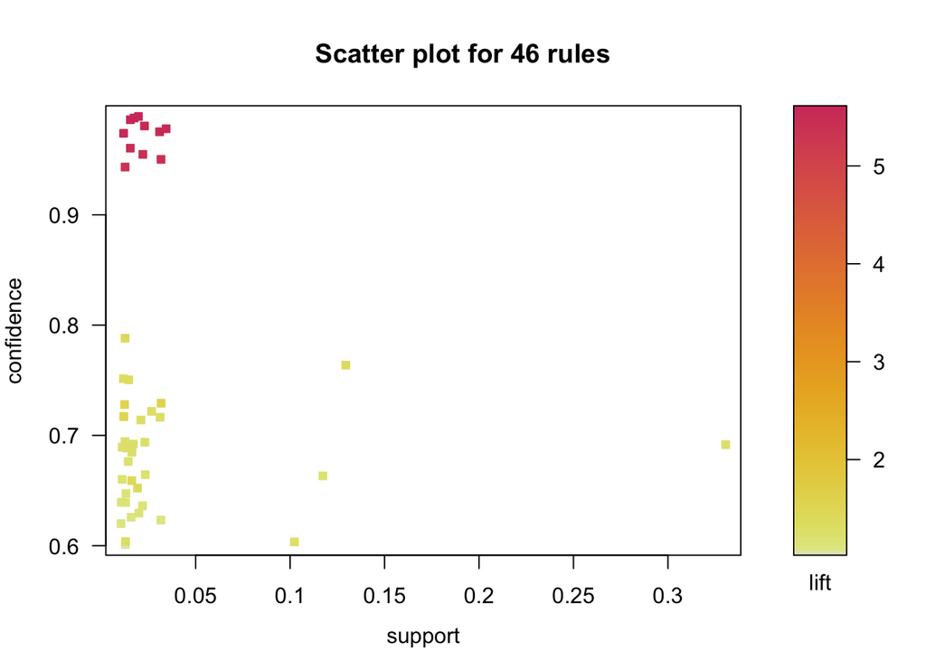

```r
#all rules together
plot(rules.50.pruned)
```

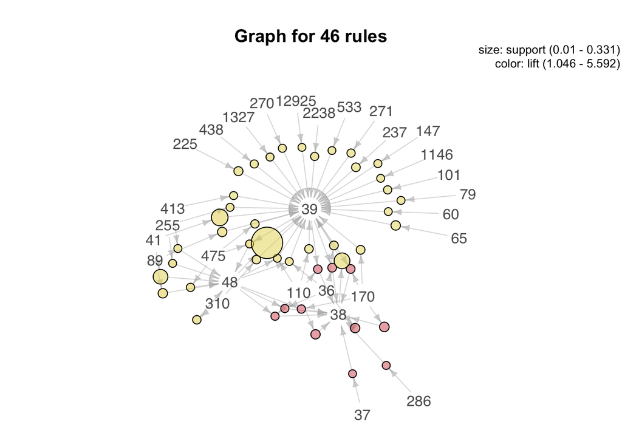

```r
plot(rules.50.pruned, method = "graph", control = list(type="items"))
```

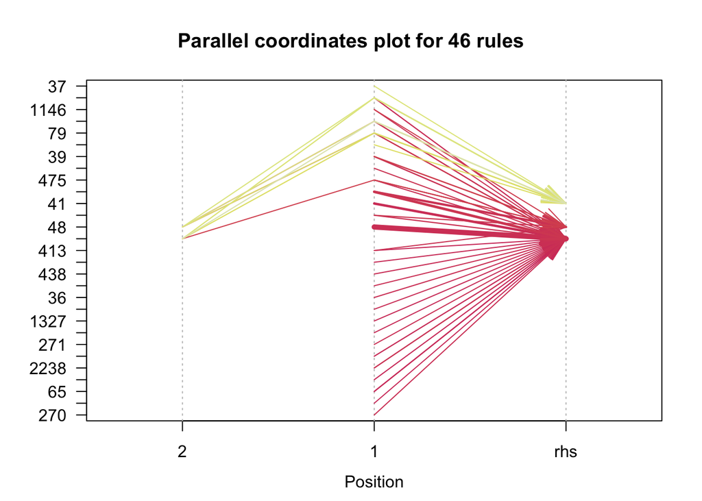

```r
plot(rules.50.pruned, method = "paracoord", control = list(reorder = TRUE))
```

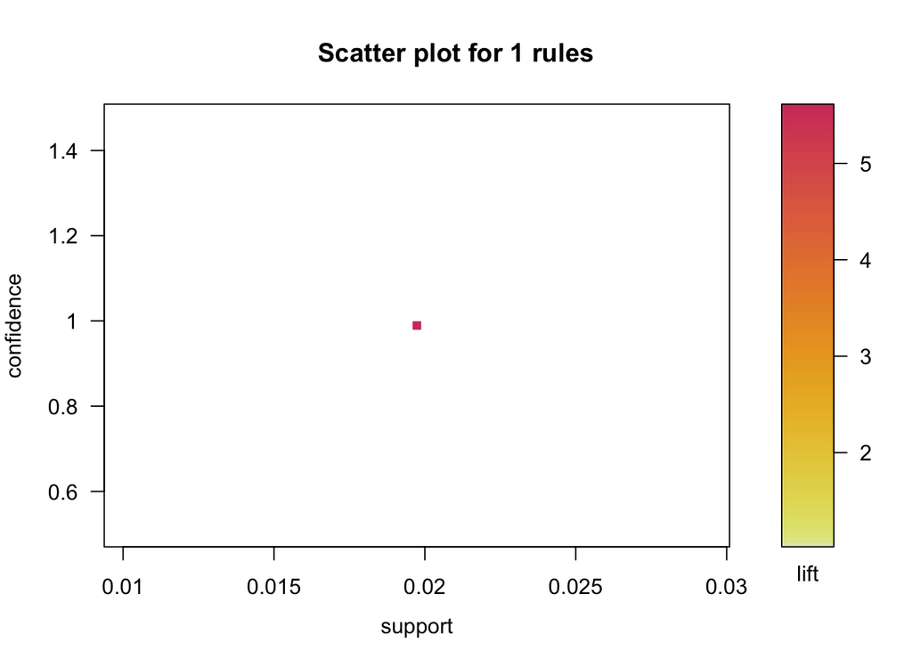

```r
#the best
plot(rules.50.pruned[1])
```

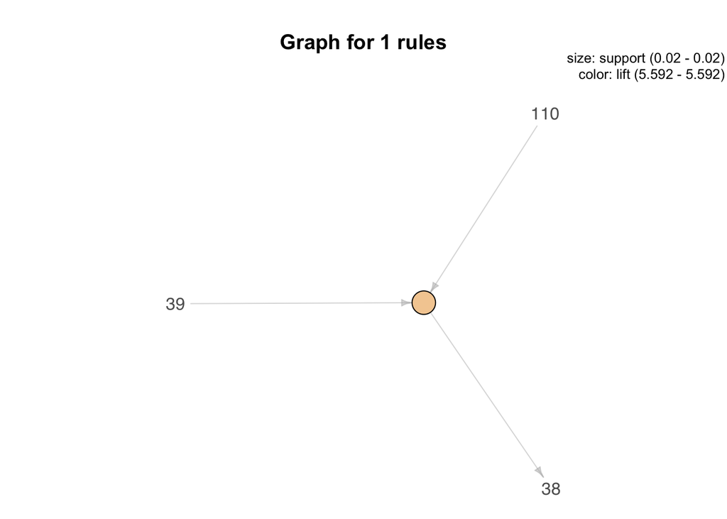

```r
plot(rules.50.pruned[1], method = "graph", control = list(type="items"))
```

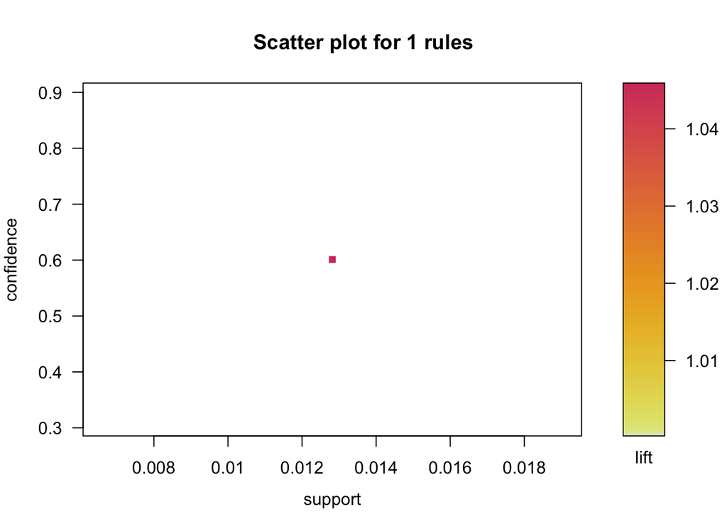

```r
#the worst
plot(rules.50.pruned[46])
```

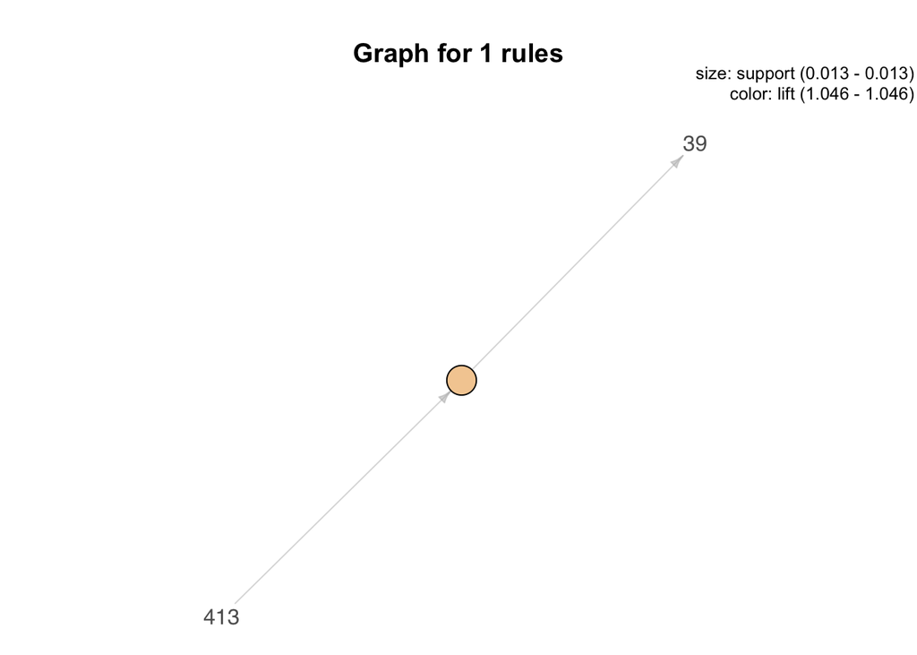

```r
plot(rules.50.pruned[46], method = "graph", control = list(type="items"))
```

### 5. Does the model make sense?

This model can figure out the association between different items, and some of the rules have a high confidence as well as lift or support.

SO this model makes sense.